# Introduction to mrgsolve Models and Events

PAGE 2019 Workshop

Metrum Research Group, LLC

# A basic simulation with mrgsolve

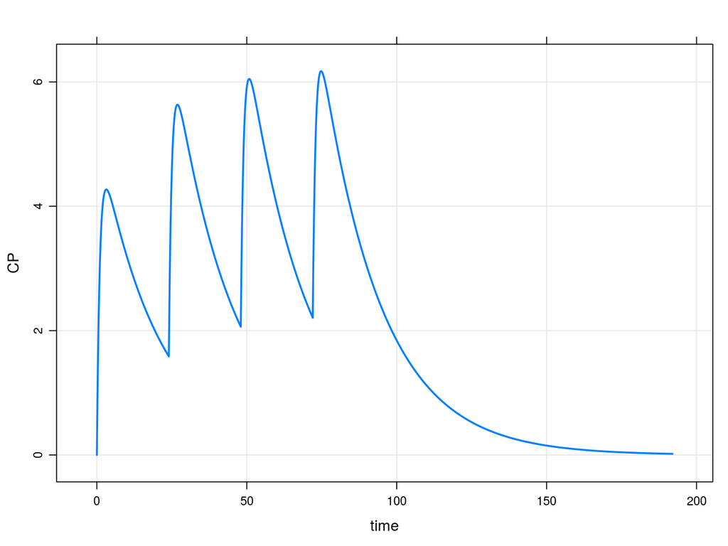

```r
mod %>% ev(amt = 100, ii = 24, addl = 3) %>% mrgsim() %>% plot()
```

# A basic simulation with mrgsolve

```r
mod %>% ev(amt = 100, ii = 24, addl = 3) %>% mrgsim() %>% plot()
```

- mod: the model object
  - Ok … where did `that` come from?
- ev(amt = 100, …) : the intervention
  - An `event` in this example
- mrgsim(): actually do the simulation
- plot(): do something with the simulation
  - `plot`, `mutate`, `as_data_frame` etc …
- model `%>%` intervention `%>%` Go! `%>%` take-a-look

# What’s coming …

- `model %>% intervention %>%` options `%>% Go! %>% ...`
- `model %>% intervention %>%` population `%>% Go! %>% ...`
- `model %>%` data-set `%>% Go! %>% ...`
- where data-set = `intervention + population`
- For now, let’s get this part down
- model `%>%` intervention `%>%` Go! `%>%` take-a-look

# Why do we use `%>%` ?

What happens first in this operation?

```r
mean(sqrt(seq(4)))
```

# Pipelines

Yuck

```r
postprocess(simulate(some_intervention(mod)))
```

Better.

```r
mod %>% some_intervention() %>% simulate() %>% post_process()
```

# The model object

model `%>% ...`

- I (almost) always call the model object mod in the documention / examples
- All the information about the model we need to know to run the simulation
- Distinct from the intervention, the population, the summary
- But the model does know about output time, random effects

# Take a look: overview

```r
mod
```

```
------------ mrgsolve model object (unix) ------------
  project: /usr/rpkgs/3.6/mrgsolve/models
  source:        pk1.cpp
  shared object: pk1-so-357c7969e2cd

  time:          start: 0 end: 192 delta: 0.2
                 add: <none>
                 tscale: 1

  compartments:  EV CENT [2]
  parameters:    CL V KA [3]
  omega:         0x0
  sigma:         0x0

  solver:        atol: 1e-08 rtol: 1e-08
                 maxsteps: 5000 hmin: 0 hmax: 0
```

# Take a look: parameters (really important)

```r
param(mod)
```

```
 Model parameters (N=3):
 name value . name value
 CL   1     | V    20
 KA   1     | .    .
```

- Parameters get a name
- Names and number of parameters gets fixed at compile time
- All parameters have a value
- Value can be modified after compile time

# Take a look: compartments

```r
init(mod)
```

```
 Model initial conditions (N=2):
 name       value . name     value
 CENT (2)   0     | EV (1)   0
```

- Every compartment gets a name
- Every compartment gets an initial condition

# Where did mod come from?

```r
mod <- mread("simple", "../model")
```

```r
mod <- mread("<model-name>", "<project-directory>")
```

- By default mrgsolve looks for the code in the file
  - model-name.cpp in
  - project-directory
- mread demo

# Read in a model object with caching

First time to read

```r
mod <- mread_cache("simple", "../model")
```

```
## Building simple ... done.
```

Next time to read

```r
mod <- mread_cache("simple", "../model")
```

```
## Loading model from cache.
```

# Internal model library

Quiz:

```r
mod <- mread("<first-argument>", "<second-argument>")
```

# Internal model library

Quiz:

```r
mod <- mread("<first-argument>", "<second-argument>")
```

```r
mod <- mread("<first-argument>", modlib())
```

```r
modlib()
```

```
## [1] "/usr/rpkgs/3.6/mrgsolve/models"
```

# Internal model library

```r
mod <- mread("effect", modlib())
```

```
## Building effect ... done.
```

```r
mod
```

```
##
##
## ------------ mrgsolve model object (unix) ------------
##   project: /usr/rpkgs/3.6/mrgsolve/models
##   source:        effect.cpp
##   shared object: effect-so-357c6b26ae32
##
##   time:          start: 0 end: 36 delta: 0.1
##                  add: <none>
##                  tscale: 1
##
##   compartments:  GUT CENT PERIPH CE [4]
##   parameters:    VC KA K10 K12 K21 E0 EMAX EC50 KEO [9]
##   omega:         0x0
##   sigma:         0x0
##
##   solver:        atol: 1e-08 rtol: 1e-08
##                  maxsteps: 5000 hmin: 0 hmax: 0
```

# Inline model specification

We haven’t covered the specifics of coding a model yet

```r
code <- '
$PARAM CL = 1, V = 20
$PKMODEL cmt = "CENT"
'
```

# Event objects

- `model %>%` intervention `%>% Go! %>% take-a-look`
- Event object = quick / easy way to implement dose or other intervention

```r
e <- ev(amt = 100)

e
```

```
## Events:
##   time cmt amt evid
## 1    0   1 100    1
```

- Defaults: `time`, `evid`, `cmt`

# Three ways to invoke

Inline

```r
mod %>% ev(amt = 100) %>% mrgsim()
```

Object via pipeline

```r
e <- ev(amt = 100)

mod %>% ev(e) %>% mrgsim()
```

As argument

```r
mod %>% mrgsim(events = e)
```

# What to include in `ev(...)`

- time event time
- cmt Event compartment
- amt Dose amount
- ii Inter-dose interval
- addl Additional doses to administer
- rate Infusion rate
- ss Set to 1 to advance to steady state
- evid Event id
- ID Subject ID (use multiple ids - ID=1:10)

# Interventions and corresponding `evid`

- Bolus dosing (`evid` 1, with `rate`==0)
- Zero order infusion (`evid` 1, with `rate` > 0)
- Other type event (`evid` 2)
  - This also forces solver reset
- Compartment reset (`evid` 3)
- Reset and dose (`evid` 4)
- Replace the amount in a specific compartment (`evid` 8)

# Create complex events - 1

What’s going to happen?

```r
e1 <- ev(amt = 200)

e2 <- ev(amt = 100, time = 24, ii = 24, addl = 4)

c(e1, e2)
```

# Create complex events - 1

What’s going to happen?

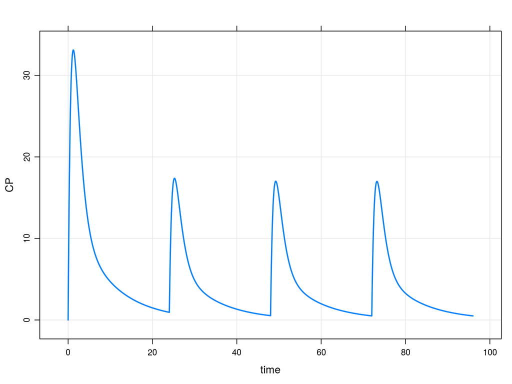

# Create complex events - 1

Combine two events

```r
e1 <- ev(amt = 200)

e2 <- ev(amt = 100, time = 24, ii = 24, addl = 4)

c(e1, e2)
```

```
## Events:
##   time cmt amt evid ii addl
## 1    0   1 200    1  0    0
## 2   24   1 100    1 24    4
```

# Create complex events - 2

What’s going to happen?

```r
e1 <- ev(amt = 200, ii = 12, addl = 2)

e2 <- ev(amt = 100, ii = 24, addl = 4)

seq(e1, e2)
```

# Create complex events - 2

What’s going to happen?

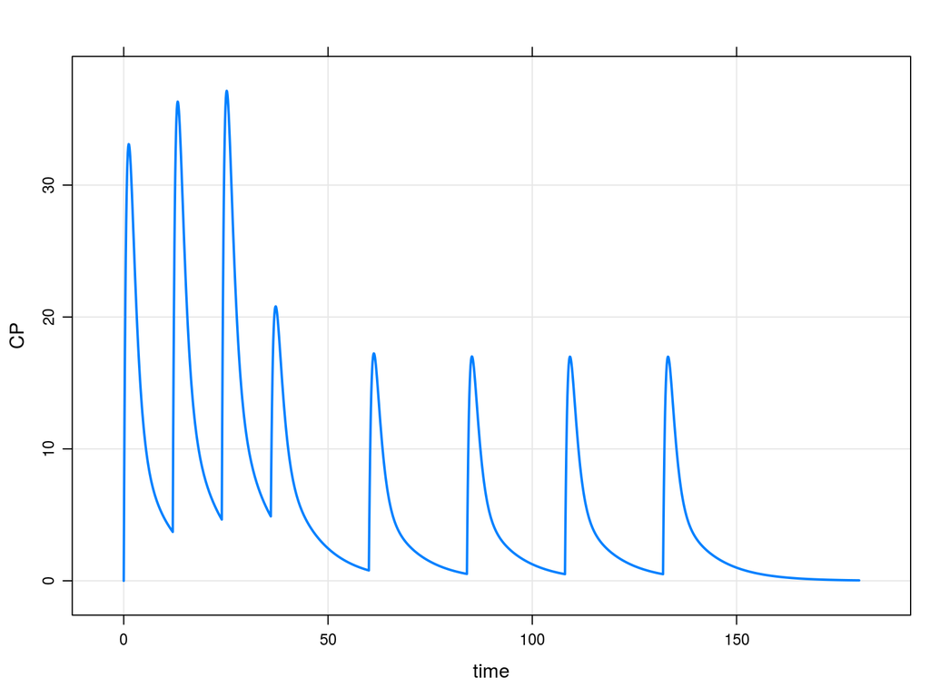

# Create complex events - 2

Put two events in a sequence

```r
e1 <- ev(amt = 200, ii = 12, addl = 2)

e2 <- ev(amt = 100, ii = 24, addl = 4)

seq(e1, e2)
```

```
## Events:
##   time cmt amt evid ii addl
## 1    0   1 200    1 12    2
## 2   36   1 100    1 24    4
```

# Create complex events - 3

What is going to happen?

```r
e1 <- ev(amt = 200)

e2 <- ev(amt = 100, ii = 24, addl = 4)

seq(e1, wait = 36, e2)
```

# Create complex events - 3

What is going to happen?

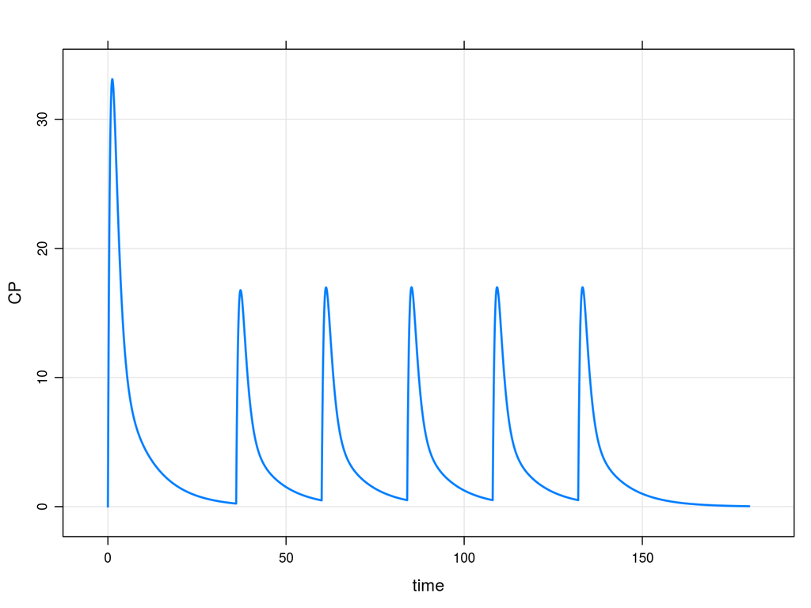

# Create complex events - 3

Wait before starting the next part of the regimen

```r
e1 <- ev(amt = 200)

e2 <- ev(amt = 100, ii = 24, addl = 4)

seq(e1, wait = 36, e2)
```

```
## Events:
##   time cmt amt evid ii addl
## 1    0   1 200    1  0    0
## 2   36   1 100    1 24    4
```

# Simulate

`model %>% intervention %>%` Go!

```r
e <- ev(amt = 100)

mod %>% ev(e) %>% mrgsim()
```

```
## Model:  effect
## Dim:    362 x 8
## Time:   0 to 36
## ID:     1
##     ID time    GUT   CENT PERIPH     CE EFFECT     CP
## 1:   1  0.0   0.00  0.000 0.0000 0.0000  157.0  0.000
## 2:   1  0.0 100.00  0.000 0.0000 0.0000  157.0  0.000
## 3:   1  0.1  91.21  8.443 0.1552 0.2225  155.7  3.460
## 4:   1  0.2  83.19 15.502 0.5817 0.8048  152.8  6.353
## 5:   1  0.3  75.88 21.354 1.2272 1.6382  149.6  8.752
## 6:   1  0.4  69.21 26.156 2.0463 2.6356  146.6 10.719
## 7:   1  0.5  63.13 30.046 3.0001 3.7278  144.1 12.314
## 8:   1  0.6  57.58 33.146 4.0553 4.8607  142.2 13.584
```

```r
mrgsim(mod, events = e)
```

# What would you like to “fix” in this plot?

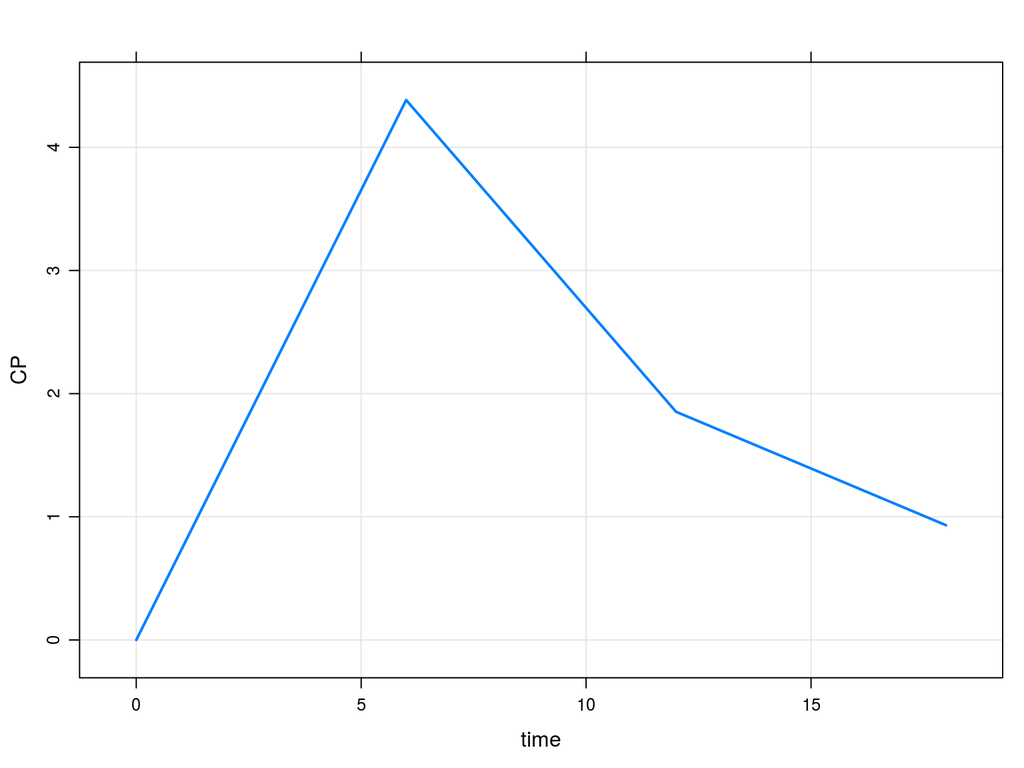

```r
mod %>% ev(amt = 100) %>% mrgsim() %>% plot(CP~time)
```

# Simulation end time

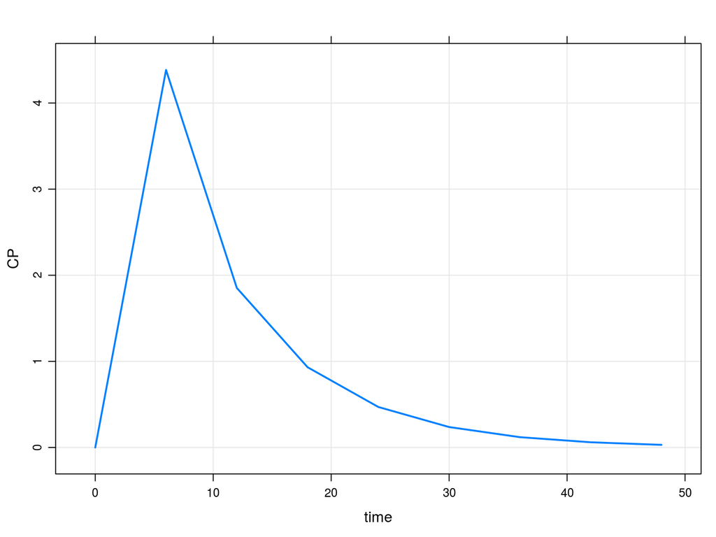

```r
mod %>% ev(amt = 100) %>% mrgsim(end = 48) %>% plot(CP~time)
```

# Simulation time step

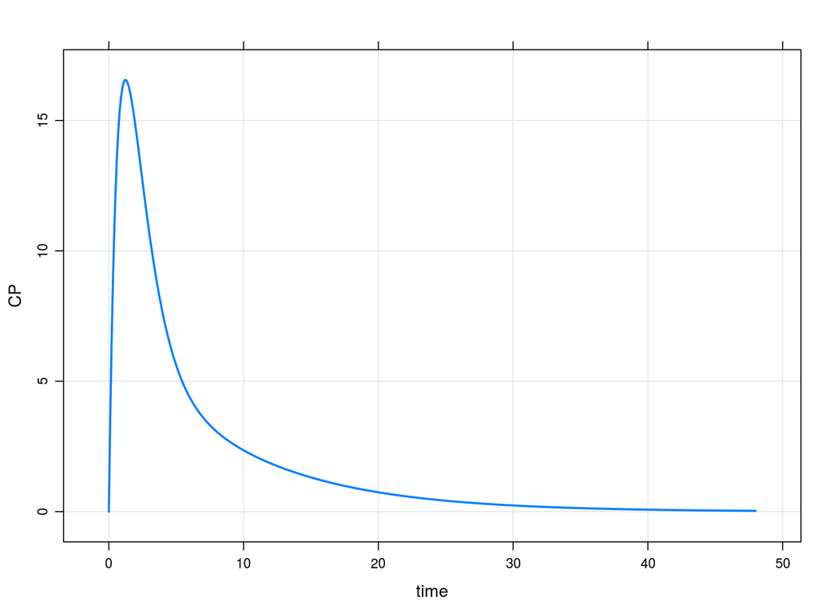

```r
mod %>% ev(amt = 100) %>% mrgsim(end = 48, delta = 0.1) %>% plot(CP~time)
```

# Simulation time grid

- To form a sequence of times
  - start usually `0`
  - end time of last observation
  - delta output time step
- Additional times to simulate
  - add ad-hoc numeric vector

```r
stime(mod)
```

```
## [1]  0  6 12 18
```

# Your turn

- File name: exercises/z-pak.R
- Section name: Z-Pak

# Event objects are just data frames

```r
as.data.frame(e1)
```

```
##   time cmt amt evid
## 1    0   1 200    1
```

- We will use a data_set later on for populations
- Event objects are convenient
  - Constructor
  - Operations

# We’re stil working on this setup

model `%>%` intervention `%>%` Go! `%>%` take-a-look

model:

- Load a model with `mread` or `mread_cache`
- Use the internal library with `mread("<model-name>", modlib())`
- Check model parameters with `param(mod)`
- Check model initial conditions with `init(mod)`
- View model code with `see(mod)`

intervention:

- `ev(...`): `amt`, `cmt`, `time`, `ii`, `addl`, `rate`
- Different ways to combine event objects

# Working with simulated output

`model %>% intervention %>% Go! %>%` take-a-look

# Plot

```r
mod <- mread_cache("effect", modlib())
```

```
## Loading model from cache.
```

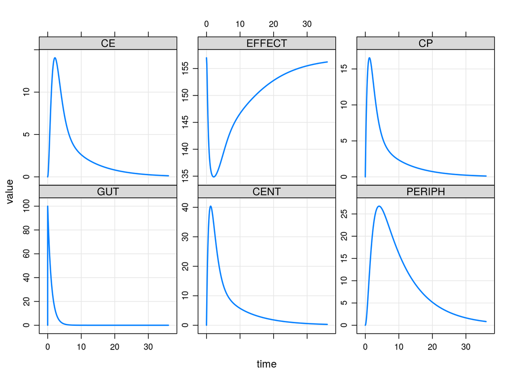

```r
mod %>% ev(amt = 100) %>% mrgsim() %>% plot()
```

# Plot

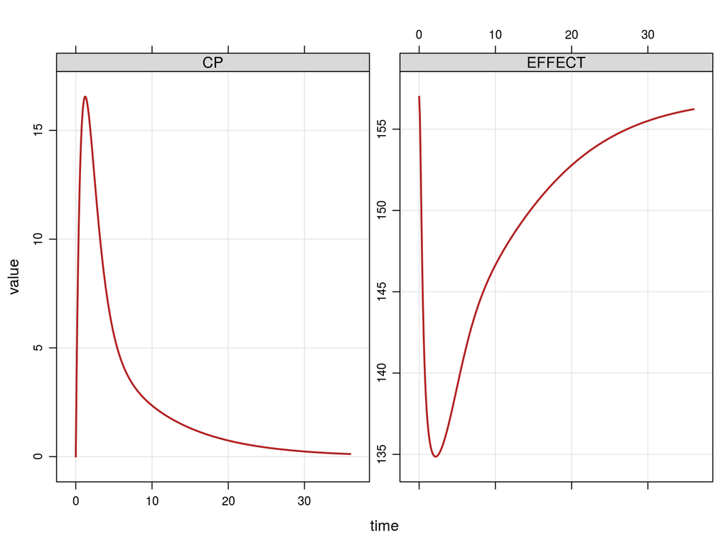

```r
mod %>% ev(amt = 100) %>% mrgsim() %>%
  plot(CP + EFFECT~., col = "firebrick")
```

# Pipeline to dplyr functions

```r
mod %>% mrgsim() %>% mutate(arm = 1)
```

```
## # A tibble: 361 x 9
##       ID  time   GUT  CENT PERIPH    CE EFFECT    CP   arm
##    <dbl> <dbl> <dbl> <dbl>  <dbl> <dbl>  <dbl> <dbl> <dbl>
##  1     1   0       0     0      0     0    157     0     1
##  2     1   0.1     0     0      0     0    157     0     1
##  3     1   0.2     0     0      0     0    157     0     1
##  4     1   0.3     0     0      0     0    157     0     1
##  5     1   0.4     0     0      0     0    157     0     1
##  6     1   0.5     0     0      0     0    157     0     1
##  7     1   0.6     0     0      0     0    157     0     1
##  8     1   0.7     0     0      0     0    157     0     1
##  9     1   0.8     0     0      0     0    157     0     1
## 10     1   0.9     0     0      0     0    157     0     1
## # … with 351 more rows
```

# Update

On the fly

```r
mod %>% update(end = 72) %>% mrgsim()
```

Persistent

```r
mod <- update(mod, end = 72)
```

mrgsim will call `update` for you (on the fly)

```r
mod %>% mrgsim(end = 72)
```

# What else can I update?

- Time
  - `start`, `end`, `delta`, `add`
- Parameters and compartment initial values
- Solver settings
  - `atol`, `rtol`
  - `hmax`, `maxsteps`, `mxhnil`, `ixpr`
- `$OMEGA`, `$SIGMA`
- `tscale` (rescale the output time)
- `digits`

```r
mod %>% update(rtol = 1E-12) %>% ...
```

```r
mod %>% mrgsim(rtol = 1E-12) %>% ...
```

# Updating parameters

- Demo

```r
mod <- param(mod, CL = 1.5)
```

# Controlling output - request

```r
mod %>% mrgsim() %>% head(n = 2)
```

```
##   ID time GUT CENT PERIPH CE EFFECT CP
## 1  1  0.0   0    0      0  0    157  0
## 2  1  0.1   0    0      0  0    157  0
```

```r
mod %>% Req(CP) %>% mrgsim() %>% head(n = 2)
```

```
##   ID time CP
## 1  1  0.0  0
## 2  1  0.1  0
```

# Controlling output - obsonly

```r
mod %>% ev(amt=1) %>% mrgsim() %>% head(n = 2)
```

```
##   ID time GUT CENT PERIPH CE EFFECT CP
## 1  1    0   0    0      0  0    157  0
## 2  1    0   1    0      0  0    157  0
```

```r
mod %>% ev(amt=1) %>% obsonly() %>% mrgsim() %>% head(n = 2)
```

```
##   ID time       GUT       CENT      PERIPH          CE   EFFECT         CP
## 1  1  0.0 0.0000000 0.00000000 0.000000000 0.000000000 157.0000 0.00000000
## 2  1  0.1 0.9121052 0.08443153 0.001551552 0.002224565 156.9866 0.03460309
```